# blog_pred

```r
# diff weights - emphasis on fundamentals
ensemble2 <- 0.5*econ_pred + 0.25*demog_pred + 0.25*poll_pred_2020$pred
ensemble_tibble2 <- tibble(pred = ensemble2, state = new_data_poll$state)

ensemble_tibble2 %>%
  mutate(state = state.abb[match(state,state.name)]) %>%
  select(state, pred) %>%
  left_join(electoral, by = "state") %>%
  mutate(state_win = case_when(pred > 50 ~ "Biden",
                            pred < 50 ~ "Trump")) %>%
  group_by(state_win) %>%
  summarise(electoral_votes = sum(`2020`)) %>%
  gt() %>%
  tab_header(title = md("**Fundamentals-Heavy Ensemble: 2020 Electoral Vote Outcome Prediction**"),
               subtitle = "BIDEN Wins") %>%
   cols_label(state_win = md("**Candidate**"),
               electoral_votes = md("**Total Electoral Votes**")) %>%
  tab_source_note(md("*Data: BEA*"))
```

**Fundamentals-Heavy Ensemble: 2020 Electoral Vote Outcome Prediction**

BIDEN Wins

| **Candidate** | **Total Electoral Votes** |
| --- | --- |
| Biden | 403 |
| Trump | 132 |

*Data: BEA*

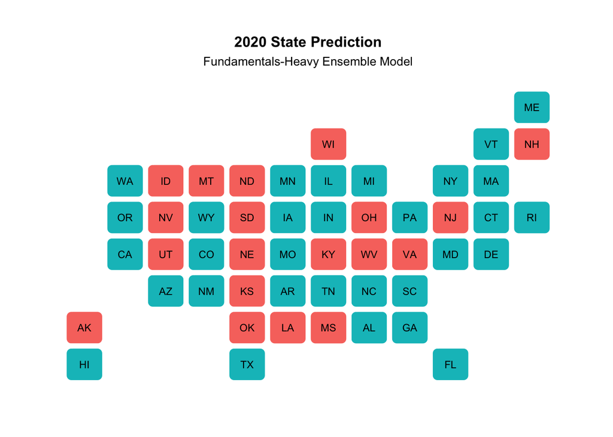

```r
# electoral map table:
ensemble_tibble2 %>%
  mutate(state = as.character(state)) %>% ##`statebins` needs state to be character, not factor!
  ggplot(aes(state = state, fill = (pred >= 50))) +
  geom_statebins() +
  theme_statebins() +
  labs(title = "2020 State Prediction",
       subtitle = "Fundamentals-Heavy Ensemble Model",
       fill = "") +
  theme(legend.position = "none",
        plot.subtitle = element_text(size = 10, hjust = 0.5),
        plot.title   = element_text(size = 12, hjust = 0.5, face = "bold"))
```

```r
# fundamentals predictive intervals:
as.data.frame(0.25*in_sample_poll + 0.25*in_sample_demo + 0.5*in_sample_econ) %>%
  mutate(state = new_data_poll$state) %>%
  select(state, lwr, fit, upr) %>%
  mutate(lwr = round(lwr,  digits = 2)/100,
         fit = round(fit, digits = 2)/100,
         upr = round(upr, digits = 2)/100)%>%
  mutate(winner =  case_when(fit > .50 ~ "Biden",
                            fit < .50 ~ "Trump")) %>%
  gt() %>%
   tab_header(title = md("**Fundamentals-Heavy Ensemble: Projected State Winners and Predictive Intervals for Democratic Vote Share Prediction**"),
               subtitle = "95% Confidence Intervals") %>%
   fmt_percent(columns = c("lwr", "fit", "upr"), decimals = 1) %>%
   cols_label(lwr = md("**Lower Bound**"),
              fit = md("**Predicted Democratic Vote Share**"),
              upr = md("**Upper Bound**"),
              state = md("**State**"),
              winner = md("**Predicted Winner**")) %>%
  tab_source_note(md("*Data: BEA, FiveThirtyEight, World Population Review*"))
```

**Fundamentals-Heavy Ensemble: Projected State Winners and Predictive Intervals for Democratic Vote Share Prediction**

95% Confidence Intervals

| **State** | **Lower Bound** | **Predicted Democratic Vote Share** | **Upper Bound** | **Predicted Winner** |
| --- | --- | --- | --- | --- |
| Alabama | 45.7% | 54.2% | 62.6% | Biden |
| Alaska | 35.3% | 43.9% | 52.5% | Trump |
| Arizona | 51.1% | 59.8% | 68.4% | Biden |
| Arkansas | 41.6% | 50.1% | 58.6% | Biden |
| California | 53.4% | 62.2% | 71.0% | Biden |
| Colorado | 46.4% | 54.9% | 63.4% | Biden |
| Connecticut | 48.0% | 56.5% | 65.0% | Biden |
| Delaware | 51.1% | 59.5% | 67.8% | Biden |
| Florida | 42.8% | 51.4% | 60.0% | Biden |
| Georgia | 46.9% | 55.6% | 64.3% | Biden |
| Hawaii | 54.0% | 70.5% | 87.0% | Biden |
| Idaho | 37.0% | 45.6% | 54.2% | Trump |
| Illinois | 47.9% | 56.4% | 64.8% | Biden |
| Indiana | 43.5% | 52.1% | 60.7% | Biden |
| Iowa | 50.3% | 58.8% | 67.3% | Biden |
| Kansas | 40.2% | 48.6% | 57.0% | Trump |
| Kentucky | 41.3% | 49.9% | 58.4% | Trump |
| Louisiana | 39.1% | 47.6% | 56.1% | Trump |
| Maine | 45.2% | 53.6% | 62.0% | Biden |
| Maryland | 45.3% | 54.1% | 62.9% | Biden |
| Massachusetts | 52.8% | 61.3% | 69.8% | Biden |
| Michigan | 44.6% | 53.2% | 61.8% | Biden |
| Minnesota | 50.4% | 59.0% | 67.6% | Biden |
| Mississippi | 37.8% | 46.2% | 54.7% | Trump |
| Missouri | 45.9% | 54.4% | 62.8% | Biden |
| Montana | 38.7% | 47.3% | 55.9% | Trump |
| Nebraska | 34.1% | 42.6% | 51.2% | Trump |
| Nevada | 36.9% | 45.4% | 53.8% | Trump |
| New Hampshire | 40.0% | 48.5% | 56.9% | Trump |
| New Jersey | 37.9% | 46.2% | 54.6% | Trump |
| New Mexico | 46.5% | 55.0% | 63.5% | Biden |
| New York | 45.7% | 54.1% | 62.5% | Biden |
| North Carolina | 45.0% | 53.7% | 62.4% | Biden |
| North Dakota | 32.3% | 40.6% | 49.0% | Trump |
| Ohio | 39.3% | 47.7% | 56.1% | Trump |
| Oklahoma | 34.1% | 42.7% | 51.3% | Trump |
| Oregon | 48.0% | 56.3% | 64.6% | Biden |
| Pennsylvania | 54.3% | 63.2% | 72.0% | Biden |
| Rhode Island | 42.1% | 50.5% | 58.9% | Biden |
| South Carolina | 44.0% | 52.8% | 61.5% | Biden |
| South Dakota | 35.1% | 43.5% | 51.8% | Trump |
| Tennessee | 45.0% | 53.6% | 62.1% | Biden |
| Texas | 45.1% | 53.7% | 62.3% | Biden |
| Utah | 30.9% | 39.3% | 47.6% | Trump |
| Vermont | 57.6% | 66.2% | 75.0% | Biden |
| Virginia | 38.0% | 46.3% | 54.5% | Trump |
| Washington | 42.2% | 50.9% | 59.6% | Biden |
| West Virginia | 36.3% | 44.6% | 52.9% | Trump |
| Wisconsin | 34.5% | 42.7% | 50.9% | Trump |
| Wyoming | 44.0% | 52.9% | 61.8% | Biden |

*Data: BEA, FiveThirtyEight, World Population Review*

# CHECKING FIT : can you even do this if it’s different years and there are some NAs?

## In Sample

```r
summary(dat)
summary(dat_change)
summary(q3_econ)

# predictions

# R-square is: 0.936


# ALTERNATIVE MODEL PREDICTION

df_poll2 <- dat %>%
  select(state, year, avg_poll)%>%
  add_predictions(fit_state_poll) %>%
  mutate(state = state.abb[match(state,state.name)])%>%
  mutate(pollpred = 0.25*pred)
df_demo2 <- dat_change %>%
  select(state, year, Black_change, Hispanic_change, Asian_change)%>%
  add_predictions(mod_demog_change) %>%
  mutate(demopred = 0.25*pred)
df_econ2 <- q3_econ %>%
  select(state, year, gdp_growth, incumbent)%>%
  add_predictions(econ_fit) %>%
  mutate(econpred = 0.5*pred)

resid2 <- df_demo2%>%
left_join(df_poll2, by = c("state", "year")) %>%
left_join(df_econ2, by = c("state", "year")) %>%
mutate(weighted_pred = pollpred + demopred + econpred) %>%
select(state, year, weighted_pred) %>%
left_join(pvstate_df, c("state", "year")) %>%
mutate(residual = D_pv2p - weighted_pred) %>%
select(state, year, weighted_pred, D_pv2p, residual) %>%
mutate(numerator = residual^2,
       denominator = (D_pv2p - mean(resid$D_pv2p, na.rm = TRUE))^2) %>%
  filter(year >= 2008)

1- (sum(resid2$numerator, na.rm = TRUE)/sum(resid2$denominator, na.rm = TRUE))

# R squared is 0.926
```

Model elements: fit_state_poll: original poll model uses dat pred_2020: poll prediction uses new_data_poll mod_demog_change: original demo model uses dat_change demog_pred: demography model prediction uses real_2020

You simply have to (1) subset out the data to leave one observation out (ex. 2016) when you estimate the regression coefficients of each model, (2) run regression and estimate the coefficients for each model, (3) do the prediction using each model with the left out data (ex. 2016) as newdata, (4) do ensemble of that prediction, and (5) compare it with the true value for ex. 2016.

## Out of Sample – can you even do this if it’s different years????

```r
true <- dat_change %>%
  left_join(df_econ, by = c("state", "year")) %>%
  filter(year == 2016) %>%
  select(year, state, D_pv2p) %>%
  distinct() %>%
  na.omit()


d <- dat_change[!(dat_change$Asian_change == 0.0000000),] %>%
  na.omit()

all_years <- seq(from=1998, to=2016, by=4)
outsamp_dflist <- lapply(all_years, function(year){

  true_inc <- true %>%
    filter(state == "FL")

  ##fundamental model out-of-sample prediction
  fit_out_poll <- lm(D_pv2p ~ avg_poll + as.factor(state), data = dat[dat$year != 2004,])
  fit_out_demo <- lm(D_pv2p ~ Black_change + Hispanic_change + Asian_change +
                         as.factor(state), data = d[d$year != 2004,])
  fit_out_econ <- lm(D_pv2p ~ gdp_growth*incumbent + as.factor(state), data = q3_econ[q3_econ$year != 2004,])

  mod_poll <- 0.5* mean(predict(fit_out_poll, dat[dat$year == 2004 & dat$state == "FL",]), na.rm = TRUE)
  mod_demog <- 0.25*predict(fit_out_demo, d[d$year == 2004 & d$state == "FL",])
  mod_econ <- 0.25*predict(fit_out_econ, q3_econ[q3_econ$year == 2004 & q3_econ$state == "FL",])

  mod <- mod_poll + mod_demog + mod_econ


  fl_margin_error = mod - true_inc$D_pv2p



        cbind(poll_winner_correct = (mod_poll > 50) == (true_inc$D_pv2p > 50),
        demo_winner_correct = (mod_demog > 50) == (true_inc$D_pv2p > 50),
        econ_winner_correct = (mod_econ > 50) == (true_inc$D_pv2p > 50))

})




sum(poll_margin_error, demo_margin_error, econ_margin_error, na.rm = T)


outsamp_df <- do.call(rbind, outsamp_dflist) #
colMeans(abs(outsamp_df[2:4]), na.rm=T) #
colMeans(outsamp_df[5:7], na.rm=T) ### classification accuracy

outsamp_df[,c("year","econ_winner_correct","poll_winner_correct","plus_winner_correct")] #
```

```r
summary(dat)
summary(dat_change)
summary(q3_econ)

# took 2016 out of the data:
out_poll <- dat %>%
  filter(year != 2016)
out_demo <- dat_change %>%
  filter(year != 2016)
out_econ <- q3_econ %>%
  filter(year != 2016)

# running regressions without 2016:
fit_out_poll <- lm(D_pv2p ~ avg_poll + as.factor(state), data = out_poll)
fit_out_demo <- lm(D_pv2p ~ Black_change + Hispanic_change + Asian_change +
                         as.factor(state), data = out_demo)
fit_out_econ <- lm(D_pv2p ~ gdp_growth*incumbent + as.factor(state), data = out_econ)

# predict without 2016
predict(fit_out_poll, newdata = out_poll)
predict(fit_out_demo, newdata = out_demo)
predict(fit_out_econ, newdata = out_econ)







outsamp_errors <- sapply(1:1000, function(i){
years_outsamp <- sample(tfc_df$year, 8)
outsamp_mod <- lm(pv2p ~ GDP_growth_qt + net_approve + incumbent, tfc_df[!(tfc_df$year %in% years_outsamp),])
outsamp_pred <- predict(outsamp_mod,
                        newdata = tfc_df[tfc_df$year %in% years_outsamp,])
outsamp_true <- tfc_df$pv2p[tfc_df$year %in% years_outsamp]
mean(outsamp_pred - outsamp_true)
})

# visualize in histogram
hist(outsamp_errors,
     xlab = "Out-of-Sample Residual",
     main = "Time-for-Change Model: \n Mean Out-of-Sample Residual (1000 Runs)",
     xlim = c(-15, 15),
     ylim = c(0, 270))

# quantify by taking the means of the outsample errors
mean(abs(outsamp_errors))















outsamp_errors <- sapply(1:1000, function(i){
  # years to omit
years_outsamp <- seq(from=2008, to=2016, by=4)
omit_data <- data[!(data$year %in% years_outsamp),]

# outsample years in each model
outsamp_mod_poll <- lm(D_pv2p ~ avg_poll + as.factor(state), omit_data)
outsamp_mod_demog <- lm(D_pv2p ~ Black_change + Hispanic_change + Asian_change +
    as.factor(state), omit_data)
outsamp_mod_econ <- lm(D_pv2p ~ gdp_growth + incumbent, omit_data)

# draw predictions from each model
outsamp_pred_poll <- omit_data %>%
  select(state, year, avg_poll)%>%
  add_predictions(outsamp_mod_poll)%>%
  mutate(pollpred = 0.5*pred)
outsamp_pred_demog <- omit_data %>%
  select(state, year, Black_change, Hispanic_change, Asian_change)%>%
  add_predictions(outsamp_mod_demog) %>%
  mutate(demopred = 0.25*pred)
outsamp_pred_econ <- omit_data %>%
  select(state, year, gdp_growth, incumbent)%>%
  add_predictions(outsamp_mod_econ) %>%
  mutate(econpred = 0.25*pred)


outsamp_pred <- 0.5*outsamp_pred_poll$pollpred + 0.25*outsamp_pred_demog$demopred + 0.25*outsamp_pred_econ$econpred

# extract true value
outsamp_true <- omit_data$D_pv2p[omit_data$year %in% years_outsamp]

mean(outsamp_pred - outsamp_true, na.rm = TRUE)
})
```

# Weighted Ensemble

- I am placing the most weight on polls,
- have as.factor state for each poll

in sample fit: .5(poll)+.25(econ)+.25(demo) true value - (.5(poll)+.25(econ)+.25(demo)) 0.5predict() + 0.25predict() + .25predict()

out of sample fit: - exclude 2016 and then do whole process and do regression parameter without 2016 - predict with ensemble fit (without 2016) and make new data = 2016 data  
- make sure new data has a column named state and states listed

There should be a column named “state” And ex. PA? Then your new data should have “state” column with “PA” in that column True value - (0.5x51 + 0.25x49 + 0.25x50)

you could do ensemble at the electoral college level (0.5x400 + 0.25x390 + 0.25x380)

# Modified Time-For-Change

- economic approval rating
- state AND national approval
- GDP/RDI Growth
- Incumbency
- Jobs
- 2020 demographics
- predict national pop_vote

polls model and demographic will have popular vote share from state

- state poll, demo, AND economic model
- maybe add incumbency indicator to either poll or economy
  - find link on slack

# DOES THIS ENSEMBLE EVEN WORK IF THERE ARE TONS OF NAs in some predictions and none in others?

```r
pop <- popvote_df %>%
  select(year, party, incumbent)

summary(dat)

poll_demo_model <- dat %>%
  left_join(dat_change, by = c("year", "state")) %>%
  filter(year >= 1992) %>%
  select(state, year, party.x, D_pv2p.x, avg_poll.x, Asian_change, Black_change, Hispanic_change, Indigenous_change, White_change) %>%
  rename(D_pv2p = D_pv2p.x,
         party = party.x,
         avg_poll = avg_poll.x)%>%
  left_join(pop, by = c("year", "party")) %>%
  select(state, year, D_pv2p,  party, incumbent, avg_poll, Asian_change, Black_change, Hispanic_change, White_change) %>%
  filter(party == "democrat")

df2<-poll_demo_model[!(poll_demo_model$Asian_change == 0.0000000),]


model <- lm(D_pv2p ~ incumbent + avg_poll + Asian_change + Black_change + Hispanic_change + as.factor(state), data = df2)
summary(model)

# data frame with new poll and state predictions
real_2020

new_data_poll %>%
  mutate(state = state.abb[match(state,state.name)]) %>%
  left_join(real_2020) %>%
  mutate(incumbent = FALSE)

main_model_prediction <- predict()
```

# Time-For-Change Model: NATIONAL

```r
# cleaning and joining data
tfc_df <- popvote_df %>%
  filter(incumbent_party) %>%
  select(year, candidate, party, pv, pv2p, incumbent) %>%
  inner_join(
    approval_df %>%
      group_by(year, president) %>%
      slice(1) %>%
      # this is a NET APPROVAL
      mutate(net_approve=approve-disapprove) %>%
      select(year, incumbent_pres=president, net_approve, poll_enddate),
    by="year"
  ) %>%
  inner_join(
    economy_df %>%
      # SECOND QUARTER GDP
      filter(quarter == 2) %>%
      select(GDP_growth_qt, year, RDI_growth, quarter),
    by="year"
  )


fit_tfc <- lm(pv2p ~ GDP_growth_qt + net_approve + incumbent, data = tfc_df)
summary(fit_tfc)

approval_df

export_summs(fit_tfc, model.names = "Time-for-Change Model: \n Relationship Between Popular Vote, \n GDP Growth, Net Approval, and Incumbency")

# 2020 second-quarter GDP
economy_df %>%
  select(year, quarter, GDP_growth_qt, RDI_growth) %>%
  filter(year == 2020,
         quarter == 3)
# 2020 second quarter approval
approval_df %>%
  filter(year == 2020) %>%
  unique() %>%
  filter(poll_startdate >= as.POSIXct("2020-04-01"),
         poll_enddate <= as.POSIXct("2020-06-30")) %>%
  mutate(net_approval = approve - disapprove) %>%
  summarise(net = mean(net_approval))


# Time for Change Prediction
a <- -9.494716
b <- -8.5 # according to Gallup in 2nd quarter
c <- TRUE

new_data <- data.frame(year = 2020, candidate = "Donald J. Trump", party = "republican", pv = NA, pv2p = NA, incumbent = TRUE, incumbent_pres = NA, net_approve = b, poll_enddate = NA, GDP_growth_qt = a, RDI_growth = NA, quarter = 2, color = "red")
  # - 31.4 decline
  # net approval: -10.2



predict(fit_tfc, newdata = new_data)

# Model Predicts Trump will get 32.43% of the vote share which is almost certainly a loss


# IN SAMPLE: adjusted R squared is 0.62: 62% of variance is explained by the model

# OUT OF SAMPLE:
# creating color vector for party id
tfc_df$color[tfc_df$party== "republican"]="red"
tfc_df$color[tfc_df$party== "democrat"]="blue"

# plotting residuals of TFC
plot(tfc_df$year, tfc_df$pv2p, type = "l",
     main = "Time-For-Change Model: \n True Popular Vote vs. Predicted Popular Vote",
     xlab = "Year",
     ylab = "Popular Vote Share",
     ylim = c(40, 65),
     xlim = c(1950, 2020))
# predicted points
points(tfc_df$year, predict(fit_tfc, tfc_df),
       col = tfc_df$color)
# legend formatting
legend("topright",
       legend = c("Actual Outcomes", "Predicted Outcomes", "   Republican", "   Democrat"),
       col = c("black", "black", "red", "blue"),
       lwd=1,
       lty=c(1,NA,NA,NA),
       pch=c(NA,1,1,1),
       merge=FALSE,
       cex = 0.7)

# outsample errors for tfc model
outsamp_errors <- sapply(1:1000, function(i){
years_outsamp <- sample(tfc_df$year, 8)
outsamp_mod <- lm(pv2p ~ GDP_growth_qt + net_approve + incumbent, tfc_df[!(tfc_df$year %in% years_outsamp),])
outsamp_pred <- predict(outsamp_mod,
                        newdata = tfc_df[tfc_df$year %in% years_outsamp,])
outsamp_true <- tfc_df$pv2p[tfc_df$year %in% years_outsamp]
mean(outsamp_pred - outsamp_true)
})

# visualize in histogram
hist(outsamp_errors,
     xlab = "Out-of-Sample Residual",
     main = "Time-for-Change Model: \n Mean Out-of-Sample Residual (1000 Runs)",
     xlim = c(-15, 15),
     ylim = c(0, 270))

# quantify by taking the means of the outsample errors
mean(abs(outsamp_errors))
```

[output not shown]